# PipelinesCrossValForwardStepwiseFeatureSelectionStatmodels

In this note, we will review what we did last week, show how to use pipelines in sklearn, use sklearn's cross_val_score, look at forward stepwise feature selection, and be introduced to the Python library modeled to look like R

Although there will be presented very formal mathematics within probability, with measures and the like, we are free to be as formal or informal as we prefer. The idea of presenting us with these formal definitions is to show us exactly what these different concepts mean.

The most important for this course is that we learn how do calculate probabilities on the computer, and can use computers as statistical tools for analysis.

Also, goal is to show how ML is done in the industry, using data through pipelines, instead of loose numpy arrays.

# Review

```python
import pandas as pd
import sklearn
import matplotlib.pyplot as plt
%matplotlib inline
```

```python
#!tail -n 14 data/adult.names  #doesnt work for me on windows
colnames = [
    'age',
    'workclass',
    'fnlwgt',
    'education',
    'education-num',
    'martial-status',
    'occupation',
    'relationship',
    'race',
    'sex',
    'cap-gain',
    'cap-loss',
    'hours-per-week',
    'native-country',
    'income'
]
```

```python
def read_data(n=None):
    colnames = [
        'age',
        'workclass',
        'fnlwgt',
        'education',
        'education-num',
        'martial-status',
        'occupation',
        'relationship',
        'race',
        'sex',
        'cap-gain',
        'cap-loss',
        'hours-per-week',
        'native-country',
        'income'
    ]
    df = pd.read_csv('IN-STK5000-Notebooks-2020/data/adult.data.gz', names=colnames)
    # Here you would usually do more checks
    # is n bigger than our data set
    # how big sample size is needed, and so on
    # but for now, we just assume the general case that n is acceptable
    if n:
        df = df.sample(n)
        df.index = range(n)

    target = (df.income == ' >50K')*1
    df.pop('income')
    return df, target
```

```python
features, target = read_data(2000)
```

Sometimes your training data may not include all the possible values for some categories. If this new category is included in your test set, then your model may blow up.

# Pipelines

Let's look at using a pipeline in sklearn.

```python
cat_columns = ['sex', 'education', 'race']
cont_columns = ['age', 'education-num']
```

```python
from sklearn.pipeline import Pipeline
from sklearn.compose import ColumnTransformer
from sklearn.neighbors import KNeighborsClassifier
from sklearn.preprocessing import OneHotEncoder, StandardScaler
```

```python
cat_trans = Pipeline(steps=[('onehot', OneHotEncoder(drop='first'))])
# if you were to not drop this first column, it would still work
# but sklearn tries to restrict some values, so its a good idea to not trust this..?
```

```python
cont_trans = Pipeline(steps=[('scale', StandardScaler())])

feature_trans = ColumnTransformer(
    transformers=[('categorical', cat_trans, cat_columns),
                  ('continuous', cont_trans, cont_columns)])

classifier = Pipeline(steps=[('feature_transform', feature_trans),
                             ('classifier', KNeighborsClassifier(n_neighbors=35))])
```

```python
classifier
```

```
Pipeline(steps=[('feature_transform',
                 ColumnTransformer(transformers=[('categorical',
                                                  Pipeline(steps=[('onehot',
                                                                   OneHotEncoder(drop='first'))]),
                                                  ['sex', 'education', 'race']),
                                                 ('continuous',
                                                  Pipeline(steps=[('scale',
                                                                   StandardScaler())]),
                                                  ['age', 'education-num'])])),
                ('classifier', KNeighborsClassifier(n_neighbors=35))])
```

```python
from sklearn import set_config  #this is somewhat a gimmick
set_config(display='diagram')
```

```python
classifier
```

# Cross-validation

```python
from sklearn.model_selection import cross_val_score
# ?cross_val_score
```

```python
cv_scores = cross_val_score(classifier, features, target, cv=20)
```

```python
cv_scores
```

[output not shown]

```python
cv_scores.mean()
```

```
0.8045
```

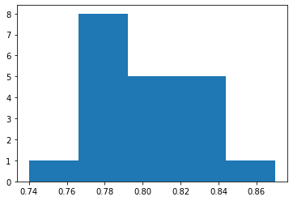

```python
plt.hist(cv_scores, bins=5)
```

```python
from sklearn.utils import resample
```

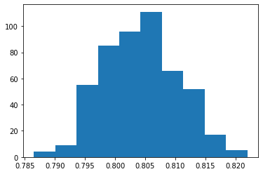

```python
plt.hist([resample(cv_scores).mean() for _ in range(500)])
```

This can be run over and over, and every time it will give slightly different results.

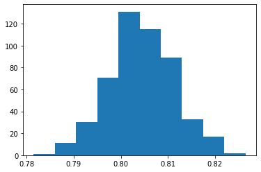

```python
plt.hist([resample(cv_scores).mean() for _ in range(500)])
None   #this is the same thing, it's just the None hides the extra infomation about the array
```

```python
ks = list(range(10, 100, 10))
```

```python
score_results = [cross_val_score(Pipeline(steps=[('feature_transform', feature_trans),
                             ('classifier', KNeighborsClassifier(n_neighbors=k))]), features, target, cv=5)
                for k in ks]
```

```python
score_results
```

```
[array([0.8025, 0.805 , 0.8   , 0.82  , 0.7925]),
 array([0.7875, 0.8075, 0.795 , 0.8025, 0.7875]),
 array([0.8   , 0.81  , 0.8175, 0.8025, 0.785 ]),
 array([0.8   , 0.8125, 0.82  , 0.81  , 0.785 ]),
 array([0.8025, 0.8275, 0.8175, 0.8125, 0.7875]),
 array([0.7975, 0.8225, 0.81  , 0.82  , 0.785 ]),
 array([0.8   , 0.8175, 0.8025, 0.815 , 0.785 ]),
 array([0.7975, 0.815 , 0.81  , 0.815 , 0.7775]),
 array([0.7925, 0.8175, 0.81  , 0.8125, 0.7825])]
```

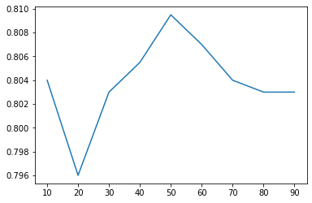

```python
plt.plot(ks, [s.mean() for s in score_results])
```

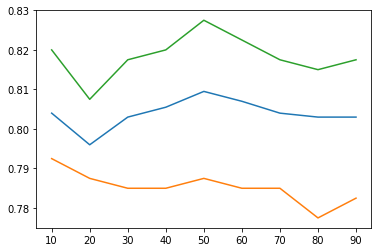

```python
plt.plot(ks, [s.mean() for s in score_results])
plt.plot(ks, [s.min() for s in score_results])
plt.plot(ks, [s.max() for s in score_results])
```

Green:max, Blue:mean, Orange:min

```python
from sklearn.model_selection import GridSearchCV
```

```python
param_grid = {'classifier__n_neighbors':ks}   # the name of the step and the parameter
grid_search = GridSearchCV(classifier, param_grid, cv=10)
```

```python
fit_result = grid_search.fit(features, target)
```

This finds the best parameters, which build your best model.

```python
fit_result.best_estimator_.get_params()['steps']
```

```
[('feature_transform', ColumnTransformer(transformers=[('categorical',
                                   Pipeline(steps=[('onehot',
                                                    OneHotEncoder(drop='first'))]),
                                   ['sex', 'education', 'race']),
                                  ('continuous',
                                   Pipeline(steps=[('scale', StandardScaler())]),
                                   ['age', 'education-num'])])),
 ('classifier', KNeighborsClassifier(n_neighbors=70))]
```

Here we see, the alg. chose n_neighbors=70 as the best number of neighbors.

```python
dummies = pd.get_dummies(features)
```

```python
dummies
```

|  | age | fnlwgt | education-num | cap-gain | cap-loss | hours-per-week | workclass_ ? | workclass_ Federal-gov | workclass_ Local-gov | workclass_ Private | ... | native-country_ Poland | native-country_ Portugal | native-country_ Puerto-Rico | native-country_ Scotland | native-country_ South | native-country_ Taiwan | native-country_ Thailand | native-country_ Trinadad&Tobago | native-country_ United-States | native-country_ Vietnam |
| --- | --- | --- | --- | --- | --- | --- | --- | --- | --- | --- | --- | --- | --- | --- | --- | --- | --- | --- | --- | --- | --- |
| 0 | 18 | 181712 | 7 | 0 | 0 | 12 | 0 | 0 | 0 | 1 | ... | 0 | 0 | 0 | 0 | 0 | 0 | 0 | 0 | 1 | 0 |
| 1 | 51 | 197656 | 10 | 0 | 0 | 45 | 0 | 0 | 0 | 1 | ... | 0 | 0 | 0 | 0 | 0 | 0 | 0 | 0 | 1 | 0 |
| 2 | 20 | 250037 | 10 | 0 | 0 | 18 | 1 | 0 | 0 | 0 | ... | 0 | 0 | 0 | 0 | 0 | 0 | 0 | 0 | 0 | 0 |
| 3 | 37 | 210945 | 9 | 0 | 0 | 24 | 0 | 0 | 0 | 1 | ... | 0 | 0 | 0 | 0 | 0 | 0 | 0 | 0 | 1 | 0 |
| 4 | 27 | 183511 | 9 | 0 | 0 | 40 | 0 | 0 | 0 | 1 | ... | 0 | 0 | 0 | 0 | 0 | 0 | 0 | 0 | 1 | 0 |
| 5 | 35 | 269300 | 13 | 0 | 0 | 60 | 0 | 0 | 0 | 0 | ... | 0 | 0 | 0 | 0 | 0 | 0 | 0 | 0 | 1 | 0 |
| 6 | 22 | 267174 | 9 | 0 | 0 | 40 | 0 | 0 | 0 | 1 | ... | 0 | 0 | 0 | 0 | 0 | 0 | 0 | 0 | 1 | 0 |
| 7 | 52 | 284129 | 10 | 0 | 0 | 40 | 0 | 0 | 0 | 1 | ... | 0 | 0 | 0 | 0 | 0 | 0 | 0 | 0 | 1 | 0 |
| 8 | 35 | 148903 | 9 | 0 | 0 | 40 | 0 | 0 | 0 | 1 | ... | 0 | 0 | 0 | 0 | 0 | 0 | 0 | 0 | 1 | 0 |
| 9 | 37 | 22463 | 11 | 0 | 1977 | 40 | 0 | 0 | 0 | 1 | ... | 0 | 0 | 0 | 0 | 0 | 0 | 0 | 0 | 1 | 0 |
| 10 | 36 | 380614 | 13 | 0 | 0 | 35 | 0 | 0 | 1 | 0 | ... | 0 | 0 | 0 | 0 | 0 | 0 | 0 | 0 | 0 | 0 |
| 11 | 36 | 301614 | 9 | 0 | 0 | 40 | 0 | 0 | 0 | 1 | ... | 0 | 0 | 0 | 0 | 0 | 0 | 0 | 0 | 1 | 0 |
| 12 | 25 | 101812 | 11 | 0 | 0 | 41 | 0 | 0 | 0 | 1 | ... | 0 | 0 | 0 | 0 | 0 | 0 | 0 | 0 | 1 | 0 |
| 13 | 36 | 77820 | 10 | 0 | 0 | 40 | 0 | 0 | 0 | 1 | ... | 0 | 0 | 0 | 0 | 0 | 0 | 0 | 0 | 1 | 0 |
| 14 | 46 | 94809 | 10 | 0 | 0 | 30 | 0 | 0 | 0 | 1 | ... | 0 | 0 | 0 | 0 | 0 | 0 | 0 | 0 | 1 | 0 |
| 15 | 45 | 184581 | 9 | 0 | 0 | 40 | 0 | 0 | 0 | 1 | ... | 0 | 0 | 0 | 0 | 0 | 0 | 0 | 0 | 1 | 0 |
| 16 | 44 | 168515 | 10 | 0 | 0 | 40 | 0 | 0 | 0 | 1 | ... | 0 | 0 | 0 | 0 | 0 | 0 | 0 | 0 | 0 | 0 |
| 17 | 56 | 35373 | 10 | 0 | 0 | 30 | 0 | 0 | 0 | 1 | ... | 0 | 0 | 0 | 0 | 0 | 0 | 0 | 0 | 1 | 0 |
| 18 | 51 | 172493 | 10 | 0 | 0 | 12 | 0 | 0 | 0 | 1 | ... | 0 | 0 | 0 | 0 | 0 | 0 | 0 | 0 | 1 | 0 |
| 19 | 26 | 164386 | 9 | 0 | 0 | 48 | 0 | 0 | 0 | 1 | ... | 0 | 0 | 0 | 0 | 0 | 0 | 0 | 0 | 1 | 0 |
| 20 | 60 | 167670 | 13 | 0 | 0 | 35 | 0 | 0 | 0 | 1 | ... | 0 | 0 | 0 | 0 | 0 | 0 | 0 | 0 | 1 | 0 |
| 21 | 56 | 198388 | 9 | 0 | 0 | 40 | 0 | 0 | 0 | 1 | ... | 0 | 0 | 0 | 0 | 0 | 0 | 0 | 0 | 1 | 0 |
| 22 | 53 | 196278 | 10 | 0 | 0 | 40 | 0 | 0 | 0 | 1 | ... | 0 | 0 | 0 | 0 | 0 | 0 | 0 | 0 | 1 | 0 |
| 23 | 29 | 207473 | 4 | 0 | 0 | 40 | 0 | 0 | 0 | 1 | ... | 0 | 0 | 0 | 0 | 0 | 0 | 0 | 0 | 0 | 0 |
| 24 | 34 | 849857 | 9 | 0 | 0 | 40 | 0 | 0 | 0 | 1 | ... | 0 | 0 | 0 | 0 | 0 | 0 | 0 | 0 | 0 | 0 |
| 25 | 60 | 178792 | 9 | 0 | 0 | 40 | 0 | 0 | 0 | 1 | ... | 0 | 0 | 0 | 0 | 0 | 0 | 0 | 0 | 1 | 0 |
| 26 | 24 | 37440 | 13 | 0 | 0 | 50 | 0 | 0 | 0 | 0 | ... | 0 | 0 | 0 | 0 | 0 | 0 | 0 | 0 | 1 | 0 |
| 27 | 42 | 269028 | 16 | 0 | 0 | 40 | 0 | 0 | 0 | 1 | ... | 0 | 0 | 0 | 0 | 0 | 0 | 0 | 0 | 0 | 0 |
| 28 | 33 | 220860 | 9 | 0 | 0 | 45 | 0 | 0 | 0 | 1 | ... | 0 | 0 | 0 | 0 | 0 | 0 | 0 | 0 | 1 | 0 |
| 29 | 43 | 144371 | 9 | 0 | 0 | 42 | 0 | 0 | 0 | 1 | ... | 0 | 0 | 0 | 0 | 0 | 0 | 0 | 0 | 1 | 0 |
| ... | ... | ... | ... | ... | ... | ... | ... | ... | ... | ... | ... | ... | ... | ... | ... | ... | ... | ... | ... | ... | ... |
| 1970 | 36 | 257942 | 9 | 0 | 0 | 40 | 0 | 0 | 0 | 1 | ... | 0 | 0 | 0 | 0 | 0 | 0 | 0 | 0 | 1 | 0 |
| 1971 | 32 | 250585 | 13 | 0 | 0 | 50 | 0 | 0 | 1 | 0 | ... | 0 | 0 | 0 | 0 | 0 | 0 | 0 | 0 | 1 | 0 |
| 1972 | 45 | 231013 | 13 | 0 | 0 | 40 | 0 | 0 | 0 | 0 | ... | 0 | 0 | 0 | 0 | 0 | 0 | 0 | 0 | 1 | 0 |
| 1973 | 24 | 196388 | 12 | 0 | 0 | 12 | 1 | 0 | 0 | 0 | ... | 0 | 0 | 0 | 0 | 0 | 0 | 0 | 0 | 1 | 0 |
| 1974 | 24 | 174391 | 9 | 0 | 0 | 40 | 0 | 0 | 0 | 0 | ... | 0 | 0 | 0 | 0 | 0 | 0 | 0 | 0 | 1 | 0 |
| 1975 | 40 | 96129 | 11 | 0 | 0 | 40 | 0 | 0 | 0 | 1 | ... | 0 | 0 | 0 | 0 | 0 | 0 | 0 | 0 | 1 | 0 |
| 1976 | 38 | 103408 | 14 | 0 | 0 | 40 | 0 | 0 | 0 | 1 | ... | 0 | 0 | 0 | 0 | 0 | 0 | 0 | 0 | 0 | 0 |
| 1977 | 54 | 32778 | 9 | 0 | 0 | 40 | 0 | 0 | 0 | 0 | ... | 0 | 0 | 0 | 0 | 0 | 0 | 0 | 0 | 1 | 0 |
| 1978 | 39 | 163204 | 9 | 0 | 0 | 40 | 0 | 0 | 0 | 0 | ... | 0 | 0 | 0 | 0 | 0 | 0 | 0 | 0 | 1 | 0 |
| 1979 | 28 | 218887 | 9 | 0 | 0 | 35 | 0 | 0 | 0 | 1 | ... | 0 | 0 | 0 | 0 | 0 | 0 | 0 | 0 | 1 | 0 |
| 1980 | 52 | 146565 | 12 | 4865 | 0 | 30 | 0 | 0 | 1 | 0 | ... | 0 | 0 | 0 | 0 | 0 | 0 | 0 | 0 | 1 | 0 |
| 1981 | 58 | 35551 | 13 | 0 | 0 | 70 | 0 | 0 | 0 | 0 | ... | 0 | 0 | 0 | 0 | 0 | 0 | 0 | 0 | 1 | 0 |
| 1982 | 29 | 175262 | 14 | 0 | 0 | 35 | 0 | 0 | 1 | 0 | ... | 0 | 0 | 0 | 0 | 0 | 0 | 0 | 0 | 1 | 0 |
| 1983 | 23 | 130905 | 13 | 0 | 0 | 40 | 0 | 0 | 0 | 1 | ... | 0 | 0 | 0 | 0 | 0 | 0 | 0 | 0 | 1 | 0 |
| 1984 | 36 | 361888 | 9 | 0 | 0 | 45 | 0 | 0 | 0 | 1 | ... | 0 | 0 | 0 | 0 | 0 | 0 | 0 | 0 | 1 | 0 |
| 1985 | 25 | 231638 | 9 | 0 | 0 | 40 | 0 | 0 | 0 | 1 | ... | 0 | 0 | 0 | 0 | 0 | 0 | 0 | 0 | 1 | 0 |
| 1986 | 36 | 33355 | 10 | 0 | 0 | 45 | 0 | 0 | 0 | 1 | ... | 0 | 0 | 0 | 0 | 0 | 0 | 0 | 0 | 1 | 0 |
| 1987 | 33 | 347623 | 14 | 0 | 0 | 40 | 0 | 0 | 0 | 1 | ... | 0 | 0 | 0 | 0 | 0 | 0 | 0 | 0 | 1 | 0 |
| 1988 | 34 | 259705 | 10 | 0 | 0 | 40 | 0 | 0 | 0 | 0 | ... | 0 | 0 | 0 | 0 | 0 | 0 | 0 | 0 | 1 | 0 |
| 1989 | 39 | 188069 | 5 | 0 | 0 | 25 | 0 | 0 | 0 | 1 | ... | 0 | 0 | 0 | 0 | 0 | 0 | 0 | 0 | 1 | 0 |
| 1990 | 36 | 408427 | 15 | 0 | 0 | 60 | 0 | 0 | 0 | 0 | ... | 0 | 0 | 0 | 0 | 0 | 0 | 0 | 0 | 1 | 0 |
| 1991 | 22 | 184813 | 10 | 0 | 0 | 40 | 0 | 0 | 0 | 1 | ... | 0 | 0 | 0 | 0 | 0 | 0 | 0 | 0 | 1 | 0 |
| 1992 | 27 | 97490 | 10 | 0 | 0 | 40 | 0 | 0 | 0 | 1 | ... | 0 | 0 | 0 | 0 | 0 | 0 | 0 | 0 | 1 | 0 |
| 1993 | 23 | 242912 | 10 | 4650 | 0 | 40 | 0 | 0 | 0 | 1 | ... | 0 | 0 | 0 | 0 | 0 | 0 | 0 | 0 | 1 | 0 |
| 1994 | 35 | 225330 | 13 | 0 | 0 | 40 | 0 | 0 | 0 | 1 | ... | 0 | 0 | 0 | 0 | 0 | 0 | 0 | 0 | 1 | 0 |
| 1995 | 17 | 659273 | 7 | 0 | 0 | 40 | 1 | 0 | 0 | 0 | ... | 0 | 0 | 0 | 0 | 0 | 0 | 0 | 1 | 0 | 0 |
| 1996 | 29 | 444304 | 13 | 0 | 0 | 40 | 0 | 0 | 0 | 1 | ... | 0 | 0 | 0 | 0 | 0 | 0 | 0 | 0 | 1 | 0 |
| 1997 | 22 | 361280 | 13 | 0 | 0 | 20 | 0 | 0 | 0 | 0 | ... | 0 | 0 | 0 | 0 | 0 | 0 | 0 | 0 | 0 | 0 |
| 1998 | 29 | 144592 | 15 | 0 | 0 | 50 | 0 | 0 | 0 | 1 | ... | 0 | 0 | 0 | 0 | 0 | 0 | 0 | 0 | 1 | 0 |
| 1999 | 53 | 124963 | 9 | 0 | 0 | 40 | 0 | 0 | 0 | 1 | ... | 0 | 0 | 0 | 0 | 0 | 0 | 0 | 0 | 1 | 0 |

2000 rows × 96 columns

```python
for column in dummies:
    corr = dummies[column].corr(target)
    print(f'{column}: {corr}')
```

```
age: 0.22814016735704712
fnlwgt: -0.024799150492211916
education-num: 0.3397232980285314
cap-gain: 0.2359292611074695
cap-loss: 0.13823150888236002
hours-per-week: 0.22025295827104138
workclass_ ?: -0.0914829218285114
workclass_ Federal-gov: 0.04609024105854122
workclass_ Local-gov: 0.05675236260087804
workclass_ Private: -0.07325341833027024
workclass_ Self-emp-inc: 0.09392855499315302
workclass_ Self-emp-not-inc: 0.05650833472330099
workclass_ State-gov: 0.005844073191832
education_ 10th: -0.07168458661673176
education_ 11th: -0.10344112056712088
education_ 12th: -0.05177660860998759
education_ 1st-4th: -0.03570984456152662
education_ 5th-6th: -0.03943900760308151
education_ 7th-8th: -0.05676922981994202
education_ 9th: -0.05601580434755568
education_ Assoc-acdm: 0.041953938030011635
education_ Assoc-voc: 0.011651741957930185
education_ Bachelors: 0.1406096267895298
education_ Doctorate: 0.16107487701848658
education_ HS-grad: -0.14269313160032704
education_ Masters: 0.18289761028809984
education_ Preschool: -0.021840331616252977
education_ Prof-school: 0.15175772772310883
education_ Some-college: -0.03722865542451165
martial-status_ Divorced: -0.11765572251583212
martial-status_ Married-AF-spouse: -0.01782809293085055
martial-status_ Married-civ-spouse: 0.4628958131050045
martial-status_ Married-spouse-absent: -0.04377942632029975
martial-status_ Never-married: -0.32841365665784134
martial-status_ Separated: -0.07991232567626222
martial-status_ Widowed: -0.09581061789613336
occupation_ ?: -0.0914829218285114
occupation_ Adm-clerical: -0.09085273949848977
occupation_ Craft-repair: -0.042108217759389055
occupation_ Exec-managerial: 0.2261996796998491
```

[output cut: 41 more lines]

```
native-country_ Japan: 0.03857552347711625
native-country_ Mexico: -0.07410292231576877
native-country_ Nicaragua: -0.02184033161625304
native-country_ Outlying-US(Guam-USVI-etc): -0.012603211844650792
native-country_ Philippines: 0.016773030554250296
native-country_ Poland: -0.025225359280069637
native-country_ Portugal: -0.017828092930850522
native-country_ Puerto-Rico: -0.01718814095077636
native-country_ Scotland: -0.01260321184465079
native-country_ South: -0.00953382656764428
native-country_ Taiwan: 0.01915965173896403
native-country_ Thailand: -0.01260321184465079
native-country_ Trinadad&Tobago: 0.019159651738963866
native-country_ United-States: 0.04836719047781544
native-country_ Vietnam: -0.030910119320210382
```

Correlation will work if you have something that looks like a linear.

# feature selection

```python
from sklearn.tree import DecisionTreeClassifier
```

```python
columns = list(features.columns)
selected_features = []
scores = []
N = 10
while len(selected_features) < N:
    best_score = pd.Series([0])
    best_feature = None
    for feature in columns:
        score = cross_val_score(DecisionTreeClassifier(max_depth=10),
                               pd.get_dummies(features[selected_features + [feature]]), target)
        if score.mean() > best_score.mean():
            best_feature = feature
            best_score = score
    print(f'{best_feature}: {best_score} ({best_score.mean()})')
    columns.remove(best_feature)
    selected_features.append(best_feature)
    scores.append(best_score)
```

```
cap-gain: [0.8225 0.835  0.7975 0.7975 0.8   ] (0.8105)
cap-loss: [0.8325 0.8375 0.815  0.8    0.81  ] (0.8190000000000002)
martial-status: [0.8325 0.845  0.82   0.805  0.8125] (0.8230000000000001)
occupation: [0.8425 0.855  0.8525 0.825  0.8475] (0.8445)
sex: [0.84   0.8475 0.855  0.825  0.85  ] (0.8434999999999999)
relationship: [0.8375 0.8475 0.8425 0.8275 0.85  ] (0.841)
workclass: [0.8375 0.855  0.8375 0.835  0.84  ] (0.841)
race: [0.8375 0.8625 0.8375 0.8275 0.81  ] (0.8350000000000002)
native-country: [0.835  0.865  0.8275 0.8225 0.81  ] (0.8320000000000001)
age: [0.835  0.8425 0.835  0.8075 0.8225] (0.8285)
```

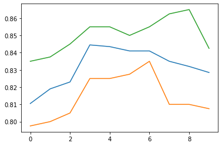

```python
plt.plot([s.mean() for s in scores])
plt.plot([s.min() for s in scores])
plt.plot([s.max() for s in scores])
```

Let's see what results we get for a completely random data set. Hint: there should be no correlation between features!

```python
import numpy
```

```python
N = 200
random_features = pd.DataFrame(numpy.random.normal(size=(N,N)))
random_target = numpy.random.choice([0, 1], size=N)
```

```python
from sklearn.model_selection import train_test_split
Xtr, Xte, ytr, yte = train_test_split(random_features, random_target, test_size=0.2)
```

```python
columns = list(Xtr.columns)
selected_features = []
scores = []
N = 5
while len(selected_features) < N:
    best_score = pd.Series([0])
    best_feature = None
    for feature in columns:
        score = cross_val_score(DecisionTreeClassifier(max_depth=10),
                               pd.get_dummies(Xtr[selected_features + [feature]]), ytr)
        if score.mean() > best_score.mean():
            best_feature = feature
            best_score = score
    print(f'{best_feature}: {best_score} ({best_score.mean()})')
    columns.remove(best_feature)
    selected_features.append(best_feature)
    scores.append(best_score)
```

```
91: [0.71875 0.75    0.4375  0.71875 0.46875] (0.61875)
9: [0.6875  0.59375 0.46875 0.65625 0.65625] (0.6125)
141: [0.5625  0.6875  0.46875 0.78125 0.6875 ] (0.6375)
121: [0.65625 0.71875 0.53125 0.6875  0.6875 ] (0.65625)
108: [0.6875  0.71875 0.53125 0.78125 0.6875 ] (0.68125)
```

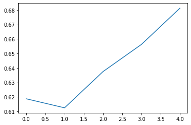

```python
plt.plot([s.mean() for s in scores])
```

```python
model = DecisionTreeClassifier(max_depth=10).fit(Xtr[selected_features], ytr)
```

```python
from sklearn.metrics import accuracy_score
```

```python
accuracy_score(yte, model.predict(Xte[selected_features]))
```

```
0.475
```

When doing feature selection:

- Use a pipeline
- Cross validate
- Use your brain to see if the features make sense

```python
cv_scores_r = cross_val_score(DecisionTreeClassifier(max_depth=10), random_features[selected_features], random_target, cv=30)
```

```python
cv_scores_r
```

```
array([0.71428571, 0.28571429, 0.28571429, 0.42857143, 0.42857143,
       0.14285714, 0.28571429, 0.71428571, 0.42857143, 0.57142857,
       0.71428571, 0.57142857, 0.71428571, 0.57142857, 0.57142857,
       0.42857143, 0.85714286, 0.71428571, 0.28571429, 0.28571429,
       0.66666667, 0.66666667, 0.5       , 0.33333333, 0.33333333,
       0.5       , 0.16666667, 1.        , 0.5       , 0.66666667])
```

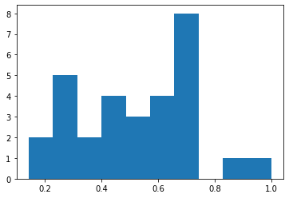

```python
plt.hist(cv_scores_r)
```

# R-ish-Library

```python
import statsmodels.formula.api as smf
```

```python
features
```

|  | age | workclass | fnlwgt | education | education-num | martial-status | occupation | relationship | race | sex | cap-gain | cap-loss | hours-per-week | native-country |
| --- | --- | --- | --- | --- | --- | --- | --- | --- | --- | --- | --- | --- | --- | --- |
| 0 | 18 | Private | 181712 | 11th | 7 | Never-married | Handlers-cleaners | Own-child | White | Male | 0 | 0 | 12 | United-States |
| 1 | 51 | Private | 197656 | Some-college | 10 | Married-civ-spouse | Exec-managerial | Husband | White | Male | 0 | 0 | 45 | United-States |
| 2 | 20 | ? | 250037 | Some-college | 10 | Never-married | ? | Own-child | White | Female | 0 | 0 | 18 | ? |
| 3 | 37 | Private | 210945 | HS-grad | 9 | Married-civ-spouse | Handlers-cleaners | Husband | White | Male | 0 | 0 | 24 | United-States |
| 4 | 27 | Private | 183511 | HS-grad | 9 | Married-civ-spouse | Handlers-cleaners | Husband | White | Male | 0 | 0 | 40 | United-States |
| 5 | 35 | Self-emp-not-inc | 269300 | Bachelors | 13 | Never-married | Other-service | Not-in-family | Black | Female | 0 | 0 | 60 | United-States |
| 6 | 22 | Private | 267174 | HS-grad | 9 | Never-married | Handlers-cleaners | Own-child | Black | Male | 0 | 0 | 40 | United-States |
| 7 | 52 | Private | 284129 | Some-college | 10 | Married-civ-spouse | Craft-repair | Husband | White | Male | 0 | 0 | 40 | United-States |
| 8 | 35 | Private | 148903 | HS-grad | 9 | Divorced | Sales | Unmarried | White | Female | 0 | 0 | 40 | United-States |
| 9 | 37 | Private | 22463 | Assoc-voc | 11 | Married-civ-spouse | Craft-repair | Husband | White | Male | 0 | 1977 | 40 | United-States |
| 10 | 36 | Local-gov | 380614 | Bachelors | 13 | Married-civ-spouse | Adm-clerical | Wife | White | Female | 0 | 0 | 35 | Germany |
| 11 | 36 | Private | 301614 | HS-grad | 9 | Married-civ-spouse | Craft-repair | Husband | White | Male | 0 | 0 | 40 | United-States |
| 12 | 25 | Private | 101812 | Assoc-voc | 11 | Married-civ-spouse | Sales | Husband | White | Male | 0 | 0 | 41 | United-States |
| 13 | 36 | Private | 77820 | Some-college | 10 | Married-civ-spouse | Craft-repair | Husband | White | Male | 0 | 0 | 40 | United-States |
| 14 | 46 | Private | 94809 | Some-college | 10 | Divorced | Priv-house-serv | Unmarried | White | Female | 0 | 0 | 30 | United-States |
| 15 | 45 | Private | 184581 | HS-grad | 9 | Married-civ-spouse | Machine-op-inspct | Husband | White | Male | 0 | 0 | 40 | United-States |
| 16 | 44 | Private | 168515 | Some-college | 10 | Divorced | Adm-clerical | Not-in-family | White | Female | 0 | 0 | 40 | Germany |
| 17 | 56 | Private | 35373 | Some-college | 10 | Divorced | Other-service | Not-in-family | White | Male | 0 | 0 | 30 | United-States |
| 18 | 51 | Private | 172493 | Some-college | 10 | Never-married | Exec-managerial | Not-in-family | White | Female | 0 | 0 | 12 | United-States |
| 19 | 26 | Private | 164386 | HS-grad | 9 | Never-married | Craft-repair | Own-child | White | Male | 0 | 0 | 48 | United-States |
| 20 | 60 | Private | 167670 | Bachelors | 13 | Married-civ-spouse | Prof-specialty | Husband | White | Male | 0 | 0 | 35 | United-States |
| 21 | 56 | Private | 198388 | HS-grad | 9 | Divorced | Adm-clerical | Not-in-family | White | Female | 0 | 0 | 40 | United-States |
| 22 | 53 | Private | 196278 | Some-college | 10 | Widowed | Sales | Not-in-family | White | Female | 0 | 0 | 40 | United-States |
| 23 | 29 | Private | 207473 | 7th-8th | 4 | Married-civ-spouse | Transport-moving | Husband | White | Male | 0 | 0 | 40 | Mexico |
| 24 | 34 | Private | 849857 | HS-grad | 9 | Married-civ-spouse | Craft-repair | Husband | White | Male | 0 | 0 | 40 | Nicaragua |
| 25 | 60 | Private | 178792 | HS-grad | 9 | Widowed | Handlers-cleaners | Not-in-family | White | Female | 0 | 0 | 40 | United-States |
| 26 | 24 | Self-emp-not-inc | 37440 | Bachelors | 13 | Never-married | Farming-fishing | Unmarried | White | Male | 0 | 0 | 50 | United-States |
| 27 | 42 | Private | 269028 | Doctorate | 16 | Married-civ-spouse | Prof-specialty | Husband | White | Male | 0 | 0 | 40 | France |
| 28 | 33 | Private | 220860 | HS-grad | 9 | Divorced | Transport-moving | Not-in-family | White | Male | 0 | 0 | 45 | United-States |
| 29 | 43 | Private | 144371 | HS-grad | 9 | Married-civ-spouse | Handlers-cleaners | Husband | White | Male | 0 | 0 | 42 | United-States |
| ... | ... | ... | ... | ... | ... | ... | ... | ... | ... | ... | ... | ... | ... | ... |
| 1970 | 36 | Private | 257942 | HS-grad | 9 | Married-civ-spouse | Sales | Husband | White | Male | 0 | 0 | 40 | United-States |
| 1971 | 32 | Local-gov | 250585 | Bachelors | 13 | Never-married | Prof-specialty | Not-in-family | White | Female | 0 | 0 | 50 | United-States |
| 1972 | 45 | State-gov | 231013 | Bachelors | 13 | Divorced | Protective-serv | Not-in-family | White | Male | 0 | 0 | 40 | United-States |
| 1973 | 24 | ? | 196388 | Assoc-acdm | 12 | Never-married | ? | Not-in-family | White | Male | 0 | 0 | 12 | United-States |
| 1974 | 24 | Self-emp-not-inc | 174391 | HS-grad | 9 | Married-civ-spouse | Adm-clerical | Wife | White | Female | 0 | 0 | 40 | United-States |
| 1975 | 40 | Private | 96129 | Assoc-voc | 11 | Married-civ-spouse | Tech-support | Husband | White | Male | 0 | 0 | 40 | United-States |
| 1976 | 38 | Private | 103408 | Masters | 14 | Married-civ-spouse | Exec-managerial | Husband | Black | Male | 0 | 0 | 40 | ? |
| 1977 | 54 | State-gov | 32778 | HS-grad | 9 | Widowed | Exec-managerial | Not-in-family | White | Female | 0 | 0 | 40 | United-States |
| 1978 | 39 | Self-emp-not-inc | 163204 | HS-grad | 9 | Married-civ-spouse | Sales | Husband | White | Male | 0 | 0 | 40 | United-States |
| 1979 | 28 | Private | 218887 | HS-grad | 9 | Never-married | Farming-fishing | Unmarried | White | Female | 0 | 0 | 35 | United-States |
| 1980 | 52 | Local-gov | 146565 | Assoc-acdm | 12 | Divorced | Other-service | Not-in-family | White | Female | 4865 | 0 | 30 | United-States |
| 1981 | 58 | Self-emp-not-inc | 35551 | Bachelors | 13 | Married-civ-spouse | Exec-managerial | Husband | White | Male | 0 | 0 | 70 | United-States |
| 1982 | 29 | Local-gov | 175262 | Masters | 14 | Married-civ-spouse | Prof-specialty | Other-relative | White | Male | 0 | 0 | 35 | United-States |
| 1983 | 23 | Private | 130905 | Bachelors | 13 | Never-married | Sales | Own-child | White | Female | 0 | 0 | 40 | United-States |
| 1984 | 36 | Private | 361888 | HS-grad | 9 | Married-civ-spouse | Transport-moving | Husband | White | Male | 0 | 0 | 45 | United-States |
| 1985 | 25 | Private | 231638 | HS-grad | 9 | Never-married | Adm-clerical | Own-child | White | Female | 0 | 0 | 40 | United-States |
| 1986 | 36 | Private | 33355 | Some-college | 10 | Never-married | Other-service | Own-child | White | Male | 0 | 0 | 45 | United-States |
| 1987 | 33 | Private | 347623 | Masters | 14 | Never-married | Exec-managerial | Unmarried | White | Male | 0 | 0 | 40 | United-States |
| 1988 | 34 | State-gov | 259705 | Some-college | 10 | Separated | Exec-managerial | Own-child | White | Female | 0 | 0 | 40 | United-States |
| 1989 | 39 | Private | 188069 | 9th | 5 | Married-civ-spouse | Transport-moving | Husband | White | Male | 0 | 0 | 25 | United-States |
| 1990 | 36 | Self-emp-not-inc | 408427 | Prof-school | 15 | Married-civ-spouse | Prof-specialty | Husband | White | Male | 0 | 0 | 60 | United-States |
| 1991 | 22 | Private | 184813 | Some-college | 10 | Never-married | Adm-clerical | Own-child | White | Male | 0 | 0 | 40 | United-States |
| 1992 | 27 | Private | 97490 | Some-college | 10 | Divorced | Craft-repair | Unmarried | White | Female | 0 | 0 | 40 | United-States |
| 1993 | 23 | Private | 242912 | Some-college | 10 | Never-married | Other-service | Own-child | White | Female | 4650 | 0 | 40 | United-States |
| 1994 | 35 | Private | 225330 | Bachelors | 13 | Never-married | Adm-clerical | Not-in-family | White | Female | 0 | 0 | 40 | United-States |
| 1995 | 17 | ? | 659273 | 11th | 7 | Never-married | ? | Own-child | Black | Female | 0 | 0 | 40 | Trinadad&Tobago |
| 1996 | 29 | Private | 444304 | Bachelors | 13 | Married-civ-spouse | Prof-specialty | Husband | White | Male | 0 | 0 | 40 | United-States |
| 1997 | 22 | Self-emp-not-inc | 361280 | Bachelors | 13 | Never-married | Prof-specialty | Own-child | Asian-Pac-Islander | Male | 0 | 0 | 20 | India |
| 1998 | 29 | Private | 144592 | Prof-school | 15 | Married-civ-spouse | Prof-specialty | Husband | White | Male | 0 | 0 | 50 | United-States |
| 1999 | 53 | Private | 124963 | HS-grad | 9 | Divorced | Handlers-cleaners | Not-in-family | White | Male | 0 | 0 | 40 | United-States |

2000 rows × 14 columns

```python
X = features.copy()
```

```python
X['target'] = target
```

```python
X
```

|  | age | workclass | fnlwgt | education | education-num | martial-status | occupation | relationship | race | sex | cap-gain | cap-loss | hours-per-week | native-country | target |
| --- | --- | --- | --- | --- | --- | --- | --- | --- | --- | --- | --- | --- | --- | --- | --- |
| 0 | 18 | Private | 181712 | 11th | 7 | Never-married | Handlers-cleaners | Own-child | White | Male | 0 | 0 | 12 | United-States | 0 |
| 1 | 51 | Private | 197656 | Some-college | 10 | Married-civ-spouse | Exec-managerial | Husband | White | Male | 0 | 0 | 45 | United-States | 1 |
| 2 | 20 | ? | 250037 | Some-college | 10 | Never-married | ? | Own-child | White | Female | 0 | 0 | 18 | ? | 0 |
| 3 | 37 | Private | 210945 | HS-grad | 9 | Married-civ-spouse | Handlers-cleaners | Husband | White | Male | 0 | 0 | 24 | United-States | 0 |
| 4 | 27 | Private | 183511 | HS-grad | 9 | Married-civ-spouse | Handlers-cleaners | Husband | White | Male | 0 | 0 | 40 | United-States | 0 |
| 5 | 35 | Self-emp-not-inc | 269300 | Bachelors | 13 | Never-married | Other-service | Not-in-family | Black | Female | 0 | 0 | 60 | United-States | 0 |
| 6 | 22 | Private | 267174 | HS-grad | 9 | Never-married | Handlers-cleaners | Own-child | Black | Male | 0 | 0 | 40 | United-States | 0 |
| 7 | 52 | Private | 284129 | Some-college | 10 | Married-civ-spouse | Craft-repair | Husband | White | Male | 0 | 0 | 40 | United-States | 1 |
| 8 | 35 | Private | 148903 | HS-grad | 9 | Divorced | Sales | Unmarried | White | Female | 0 | 0 | 40 | United-States | 0 |
| 9 | 37 | Private | 22463 | Assoc-voc | 11 | Married-civ-spouse | Craft-repair | Husband | White | Male | 0 | 1977 | 40 | United-States | 1 |
| 10 | 36 | Local-gov | 380614 | Bachelors | 13 | Married-civ-spouse | Adm-clerical | Wife | White | Female | 0 | 0 | 35 | Germany | 1 |
| 11 | 36 | Private | 301614 | HS-grad | 9 | Married-civ-spouse | Craft-repair | Husband | White | Male | 0 | 0 | 40 | United-States | 0 |
| 12 | 25 | Private | 101812 | Assoc-voc | 11 | Married-civ-spouse | Sales | Husband | White | Male | 0 | 0 | 41 | United-States | 0 |
| 13 | 36 | Private | 77820 | Some-college | 10 | Married-civ-spouse | Craft-repair | Husband | White | Male | 0 | 0 | 40 | United-States | 1 |
| 14 | 46 | Private | 94809 | Some-college | 10 | Divorced | Priv-house-serv | Unmarried | White | Female | 0 | 0 | 30 | United-States | 0 |
| 15 | 45 | Private | 184581 | HS-grad | 9 | Married-civ-spouse | Machine-op-inspct | Husband | White | Male | 0 | 0 | 40 | United-States | 0 |
| 16 | 44 | Private | 168515 | Some-college | 10 | Divorced | Adm-clerical | Not-in-family | White | Female | 0 | 0 | 40 | Germany | 0 |
| 17 | 56 | Private | 35373 | Some-college | 10 | Divorced | Other-service | Not-in-family | White | Male | 0 | 0 | 30 | United-States | 0 |
| 18 | 51 | Private | 172493 | Some-college | 10 | Never-married | Exec-managerial | Not-in-family | White | Female | 0 | 0 | 12 | United-States | 0 |
| 19 | 26 | Private | 164386 | HS-grad | 9 | Never-married | Craft-repair | Own-child | White | Male | 0 | 0 | 48 | United-States | 0 |
| 20 | 60 | Private | 167670 | Bachelors | 13 | Married-civ-spouse | Prof-specialty | Husband | White | Male | 0 | 0 | 35 | United-States | 0 |
| 21 | 56 | Private | 198388 | HS-grad | 9 | Divorced | Adm-clerical | Not-in-family | White | Female | 0 | 0 | 40 | United-States | 0 |
| 22 | 53 | Private | 196278 | Some-college | 10 | Widowed | Sales | Not-in-family | White | Female | 0 | 0 | 40 | United-States | 0 |
| 23 | 29 | Private | 207473 | 7th-8th | 4 | Married-civ-spouse | Transport-moving | Husband | White | Male | 0 | 0 | 40 | Mexico | 0 |
| 24 | 34 | Private | 849857 | HS-grad | 9 | Married-civ-spouse | Craft-repair | Husband | White | Male | 0 | 0 | 40 | Nicaragua | 0 |
| 25 | 60 | Private | 178792 | HS-grad | 9 | Widowed | Handlers-cleaners | Not-in-family | White | Female | 0 | 0 | 40 | United-States | 0 |
| 26 | 24 | Self-emp-not-inc | 37440 | Bachelors | 13 | Never-married | Farming-fishing | Unmarried | White | Male | 0 | 0 | 50 | United-States | 0 |
| 27 | 42 | Private | 269028 | Doctorate | 16 | Married-civ-spouse | Prof-specialty | Husband | White | Male | 0 | 0 | 40 | France | 0 |
| 28 | 33 | Private | 220860 | HS-grad | 9 | Divorced | Transport-moving | Not-in-family | White | Male | 0 | 0 | 45 | United-States | 0 |
| 29 | 43 | Private | 144371 | HS-grad | 9 | Married-civ-spouse | Handlers-cleaners | Husband | White | Male | 0 | 0 | 42 | United-States | 1 |
| ... | ... | ... | ... | ... | ... | ... | ... | ... | ... | ... | ... | ... | ... | ... | ... |
| 1970 | 36 | Private | 257942 | HS-grad | 9 | Married-civ-spouse | Sales | Husband | White | Male | 0 | 0 | 40 | United-States | 0 |
| 1971 | 32 | Local-gov | 250585 | Bachelors | 13 | Never-married | Prof-specialty | Not-in-family | White | Female | 0 | 0 | 50 | United-States | 0 |
| 1972 | 45 | State-gov | 231013 | Bachelors | 13 | Divorced | Protective-serv | Not-in-family | White | Male | 0 | 0 | 40 | United-States | 0 |
| 1973 | 24 | ? | 196388 | Assoc-acdm | 12 | Never-married | ? | Not-in-family | White | Male | 0 | 0 | 12 | United-States | 0 |
| 1974 | 24 | Self-emp-not-inc | 174391 | HS-grad | 9 | Married-civ-spouse | Adm-clerical | Wife | White | Female | 0 | 0 | 40 | United-States | 0 |
| 1975 | 40 | Private | 96129 | Assoc-voc | 11 | Married-civ-spouse | Tech-support | Husband | White | Male | 0 | 0 | 40 | United-States | 1 |
| 1976 | 38 | Private | 103408 | Masters | 14 | Married-civ-spouse | Exec-managerial | Husband | Black | Male | 0 | 0 | 40 | ? | 0 |
| 1977 | 54 | State-gov | 32778 | HS-grad | 9 | Widowed | Exec-managerial | Not-in-family | White | Female | 0 | 0 | 40 | United-States | 0 |
| 1978 | 39 | Self-emp-not-inc | 163204 | HS-grad | 9 | Married-civ-spouse | Sales | Husband | White | Male | 0 | 0 | 40 | United-States | 0 |
| 1979 | 28 | Private | 218887 | HS-grad | 9 | Never-married | Farming-fishing | Unmarried | White | Female | 0 | 0 | 35 | United-States | 0 |
| 1980 | 52 | Local-gov | 146565 | Assoc-acdm | 12 | Divorced | Other-service | Not-in-family | White | Female | 4865 | 0 | 30 | United-States | 0 |
| 1981 | 58 | Self-emp-not-inc | 35551 | Bachelors | 13 | Married-civ-spouse | Exec-managerial | Husband | White | Male | 0 | 0 | 70 | United-States | 1 |
| 1982 | 29 | Local-gov | 175262 | Masters | 14 | Married-civ-spouse | Prof-specialty | Other-relative | White | Male | 0 | 0 | 35 | United-States | 0 |
| 1983 | 23 | Private | 130905 | Bachelors | 13 | Never-married | Sales | Own-child | White | Female | 0 | 0 | 40 | United-States | 0 |
| 1984 | 36 | Private | 361888 | HS-grad | 9 | Married-civ-spouse | Transport-moving | Husband | White | Male | 0 | 0 | 45 | United-States | 1 |
| 1985 | 25 | Private | 231638 | HS-grad | 9 | Never-married | Adm-clerical | Own-child | White | Female | 0 | 0 | 40 | United-States | 0 |
| 1986 | 36 | Private | 33355 | Some-college | 10 | Never-married | Other-service | Own-child | White | Male | 0 | 0 | 45 | United-States | 0 |
| 1987 | 33 | Private | 347623 | Masters | 14 | Never-married | Exec-managerial | Unmarried | White | Male | 0 | 0 | 40 | United-States | 0 |
| 1988 | 34 | State-gov | 259705 | Some-college | 10 | Separated | Exec-managerial | Own-child | White | Female | 0 | 0 | 40 | United-States | 0 |
| 1989 | 39 | Private | 188069 | 9th | 5 | Married-civ-spouse | Transport-moving | Husband | White | Male | 0 | 0 | 25 | United-States | 0 |
| 1990 | 36 | Self-emp-not-inc | 408427 | Prof-school | 15 | Married-civ-spouse | Prof-specialty | Husband | White | Male | 0 | 0 | 60 | United-States | 1 |
| 1991 | 22 | Private | 184813 | Some-college | 10 | Never-married | Adm-clerical | Own-child | White | Male | 0 | 0 | 40 | United-States | 0 |
| 1992 | 27 | Private | 97490 | Some-college | 10 | Divorced | Craft-repair | Unmarried | White | Female | 0 | 0 | 40 | United-States | 0 |
| 1993 | 23 | Private | 242912 | Some-college | 10 | Never-married | Other-service | Own-child | White | Female | 4650 | 0 | 40 | United-States | 0 |
| 1994 | 35 | Private | 225330 | Bachelors | 13 | Never-married | Adm-clerical | Not-in-family | White | Female | 0 | 0 | 40 | United-States | 0 |
| 1995 | 17 | ? | 659273 | 11th | 7 | Never-married | ? | Own-child | Black | Female | 0 | 0 | 40 | Trinadad&Tobago | 0 |
| 1996 | 29 | Private | 444304 | Bachelors | 13 | Married-civ-spouse | Prof-specialty | Husband | White | Male | 0 | 0 | 40 | United-States | 1 |
| 1997 | 22 | Self-emp-not-inc | 361280 | Bachelors | 13 | Never-married | Prof-specialty | Own-child | Asian-Pac-Islander | Male | 0 | 0 | 20 | India | 0 |
| 1998 | 29 | Private | 144592 | Prof-school | 15 | Married-civ-spouse | Prof-specialty | Husband | White | Male | 0 | 0 | 50 | United-States | 1 |
| 1999 | 53 | Private | 124963 | HS-grad | 9 | Divorced | Handlers-cleaners | Not-in-family | White | Male | 0 | 0 | 40 | United-States | 0 |

2000 rows × 15 columns

```python
sm_fit = smf.logit("target ~ age + Q('education-num') + sex + race", data=X).fit()  #logistic regression
```

```
Optimization terminated successfully.
         Current function value: 0.436169
         Iterations 7
```

```python
sm_fit.summary()
```

Logit Regression Results

| Dep. Variable: | target | No. Observations: | 2000 |
| --- | --- | --- | --- |
| Model: | Logit | Df Residuals: | 1992 |
| Method: | MLE | Df Model: | 7 |
| Date: | Fri, 04 Sep 2020 | Pseudo R-squ.: | 0.2102 |
| Time: | 16:31:32 | Log-Likelihood: | -872.34 |
| converged: | True | LL-Null: | -1104.5 |
| Covariance Type: | nonrobust | LLR p-value: | 3.873e-96 |

|  | coef | std err | z | P>\|z\| | [0.025 | 0.975] |
| --- | --- | --- | --- | --- | --- | --- |
| Intercept | -7.5958 | 0.782 | -9.710 | 0.000 | -9.129 | -6.063 |
| sex[T. Male] | 1.4136 | 0.150 | 9.412 | 0.000 | 1.119 | 1.708 |
| race[T. Asian-Pac-Islander] | 0.0090 | 0.754 | 0.012 | 0.990 | -1.468 | 1.486 |
| race[T. Black] | -0.5895 | 0.735 | -0.803 | 0.422 | -2.029 | 0.850 |
| race[T. Other] | -0.7432 | 1.048 | -0.709 | 0.478 | -2.797 | 1.311 |
| race[T. White] | -0.1541 | 0.694 | -0.222 | 0.824 | -1.513 | 1.205 |
| age | 0.0406 | 0.005 | 8.879 | 0.000 | 0.032 | 0.050 |
| Q('education-num') | 0.3711 | 0.027 | 13.873 | 0.000 | 0.319 | 0.424 |